# Project-1

Chuanni He

2022-09-07

# Data Processing

The first step is to read in one section fo the data using the following code:

```r
# Read in the data
library(tidyverse)
library(readr)
sheet1 = read_csv("https://www4.stat.ncsu.edu/~online/datasets/EDU01a.csv")
```

In order to finish step 1, we use `select` function to select the variables, then rename the variable.

```r
# Step 1
sheet1_selected = select(as_tibble(sheet1),Area_name, STCOU, ends_with("D"))
colnames(sheet1_selected)[1] = "area_name"
```

Next, we use `pivot_longer` function to change the data to long format.

```r
# Step 2
sheet1_long = pivot_longer(sheet1_selected, cols = 3:12, names_to = "ID", values_to = "enrollment_value")
```

Since we do not know how may years are recorded, we assume value less than 30 are from 21th century and values that are 30 and above are from the 20th century. By simply change the data type to numeric, and add the century years (1900 or 2000), we can add the `year` variable accordingly.

```r
# Step 3
year = as.numeric(substr(sheet1_long$ID, 8,9))

for (i in 1:length(year)) {
  if (year[i]<30) {year[i] = year[i]+2000} else {year[i] = year[i]+1900}
}

grab = substr(sheet1_long$ID, 1,7)

sheet1_with_year_grab = cbind(sheet1_long,year, grab)
```

Use the provided code to identify the index for `county` dataset. Then find the complementary index to establish the dataset `state`.

```r
# Step 4
sheet1_county = as_tibble(sheet1_with_year_grab[grep(pattern = ", \\w\\w", sheet1_with_year_grab$area_name),])

index = subset(1:nrow(sheet1_with_year_grab), !(1:nrow(sheet1_with_year_grab) %in% grep(pattern = ", \\w\\w", sheet1_with_year_grab$area_name)))
sheet1_state = as_tibble(sheet1_with_year_grab[index,])

# class to the tibble
class(sheet1_county) = c("county", class(sheet1_county))
class(sheet1_state)  = c("state", class(sheet1_state))
```

Use the `mutate` function to add the new `state` varuable for the `county` dataset.

```r
# Step 5
sheet1_county = mutate(sheet1_county,state = substr(sheet1_county$area_name,(nchar(sheet1_county$area_name) - 1), nchar(sheet1_county$area_name)))
```

We need to first build an index which stores all the division information. Then use `%in%` syntax to judge which division a stage belongs to, and store the information to the `division` variable.

```r
# Step 6
D1 = tolower(c("Connecticut", "Maine", "Massachusetts", "New Hampshire", "Rhode Island", "Vermont"))
D2 = tolower(c("New Jersey", "New York", "Pennsylvania"))
D3 = tolower(c("Illinois", "Indiana", "Michigan", "Ohio", "Wisconsin"))
D4 = tolower(c("Iowa", "Kansas", "Minnesota", "Missouri", "Nebraska", "North Dakota", "South Dakota"))
D5 = tolower(c("Delaware", "Florida", "Georgia", "Maryland", "North Carolina", "South Carolina", "Virginia", "District of Columbia", "West Virginia"))
D6 = tolower(c("Alabama", "Kentucky", "Mississippi", "Tennessee"))
D7 = tolower(c("Arkansas", "Louisiana", "Oklahoma", "Texas"))
D8 = tolower(c("Arizona", "Colorado", "Idaho", "Montana", "Nevada", "New Mexico", "Utah", "Wyoming"))
D9 = tolower(c("Alaska", "California", "Hawaii", "Oregon", "Washington"))

division = c()

for (i in 1:nrow(sheet1_state)) {
  if (tolower(sheet1_state$area_name[i]) %in% D1) {
    division[i]="division 1"
  } else if (tolower(sheet1_state$area_name[i]) %in% D2) {
      division[i]="division 2"
  } else if (tolower(sheet1_state$area_name[i]) %in% D3) {
        division[i]="division 3"
  } else if (tolower(sheet1_state$area_name[i]) %in% D4) {
          division[i]="division 4"
  } else if (tolower(sheet1_state$area_name[i]) %in% D5) {
            division[i]="division 5"
  } else if (tolower(sheet1_state$area_name[i]) %in% D6) {
              division[i]="division 6"
  } else if (tolower(sheet1_state$area_name[i]) %in% D7) {
                division[i]="division 7"
  } else if (tolower(sheet1_state$area_name[i]) %in% D8) {
                  division[i]="division 8"
  } else if (tolower(sheet1_state$area_name[i]) %in% D9) {
                    division[i]="division 9"
  } else {
                      division[i]="ERROR"
         }
  }
sheet1_state = mutate(sheet1_state, division)
```

# Separate Functions

Making the corresponding functions just need to change the global variables to local function-based variables.

```r
sheet2 = read_csv("https://www4.stat.ncsu.edu/~online/datasets/EDU01b.csv")

# Function for step 1&2
fun1 = function(dat,value = "enrollment_value") {
  dat_selected = select(as_tibble(dat),Area_name, STCOU, ends_with("D"))
  colnames(dat_selected)[1] = "area_name"
  dat_long = pivot_longer(dat_selected, cols = 3:12, names_to = "ID", values_to = value)
  return(dat_long)
}

# Function for step 3
fun2 = function(dat) {
  year = as.numeric(substr(dat$ID, 8,9))
  for (i in 1:length(year)) {
  if (year[i]<30) {year[i] = year[i]+2000} else {year[i] = year[i]+1900}
  }
  grab = substr(dat$ID, 1,7)
  dat_with_year_grab = cbind(dat,year,grab)
  return(dat_with_year_grab)
}

# Function for step 5
fun3 = function(dat) {
  dat_new = mutate(dat,state = substr(dat$area_name,(nchar(dat$area_name) - 1), nchar(dat$area_name)))
  return(dat_new)
  }

# Function for step 6
fun4 = function(dat) {
  D1 = tolower(c("Connecticut", "Maine", "Massachusetts", "New Hampshire", "Rhode Island", "Vermont"))
  D2 = tolower(c("New Jersey", "New York", "Pennsylvania"))
  D3 = tolower(c("Illinois", "Indiana", "Michigan", "Ohio", "Wisconsin"))
  D4 = tolower(c("Iowa", "Kansas", "Minnesota", "Missouri", "Nebraska", "North Dakota", "South Dakota"))
  D5 = tolower(c("Delaware", "Florida", "Georgia", "Maryland", "North Carolina", "South Carolina", "Virginia", "District of Columbia", "West Virginia"))
  D6 = tolower(c("Alabama", "Kentucky", "Mississippi", "Tennessee"))
  D7 = tolower(c("Arkansas", "Louisiana", "Oklahoma", "Texas"))
  D8 = tolower(c("Arizona", "Colorado", "Idaho", "Montana", "Nevada", "New Mexico", "Utah", "Wyoming"))
  D9 = tolower(c("Alaska", "California", "Hawaii", "Oregon", "Washington"))

  division = c()

  for (i in 1:nrow(dat)) {
  if (tolower(dat$area_name[i]) %in% D1) {
    division[i]="division 1"
  } else if (tolower(dat$area_name[i]) %in% D2) {
      division[i]="division 2"
  } else if (tolower(dat$area_name[i]) %in% D3) {
        division[i]="division 3"
  } else if (tolower(dat$area_name[i]) %in% D4) {
          division[i]="division 4"
  } else if (tolower(dat$area_name[i]) %in% D5) {
            division[i]="division 5"
  } else if (tolower(dat$area_name[i]) %in% D6) {
              division[i]="division 6"
  } else if (tolower(dat$area_name[i]) %in% D7) {
                division[i]="division 7"
  } else if (tolower(dat$area_name[i]) %in% D8) {
                  division[i]="division 8"
  } else if (tolower(dat$area_name[i]) %in% D9) {
                    division[i]="division 9"
  } else {
                      division[i]="ERROR"
         }
  }

  dat = mutate(dat, division)

  return(dat)
}

# Function for step 4
## Can only use list to return both tibbles
fun5 = function(dat) {
  county = as_tibble(dat[grep(pattern = ", \\w\\w", dat$area_name),])

  index = subset(1:nrow(dat), !(1:nrow(dat) %in% grep(pattern = ", \\w\\w", dat$area_name)))
  state = as_tibble(dat[index,])

  county_out = fun3(county)
  state_out = fun4(state)

  class(county_out) = c("county", class(county_out))
  class(state_out)  = c("state", class(state_out))

  return(list(county_out, state_out))
}
```

Functions in the wrap up function needs to take the corresponding inputs from previous functions by carefully arrange the local variables.

```r
# Wrap the functions
my_wrapper = function(url, value = "enrollment_value") {
  a = read_csv(url)
  b = fun1(a, value)
  c = fun2(b)
  d = fun5(c)

  return(d)
}
```

# Call It and Combine Your Data

Now we call the wrapper function using the two datasets mentioned above. Then write the function to combine county with county, and state with state using `bind_row` function. We further use a `list` object to integrate the two outputs into a sigle object.

```r
sheet1_result = my_wrapper("https://www4.stat.ncsu.edu/~online/datasets/EDU01a.csv", value = "enrollment_value")
sheet2_result = my_wrapper("https://www4.stat.ncsu.edu/~online/datasets/EDU01b.csv", value = "enrollment_value")
fun6 = function(result1, result2) {
  bind_county = bind_rows(list(result1[1],result2[1]))
  bind_state = bind_rows(list(result1[2],result2[2]))
  bind  = list(bind_county,bind_state)
  return(bind)
}

bind = fun6(sheet1_result,sheet2_result)
```

# Write a Generic Function for Summarizing

Write a `plot` function which specified the class type for plot. For `state` class, plot by years and colored by divisions. For `county` class, identify the state to be selected, calculate the mean, obtain the top/bottom values, then use the `area_name` to filter the original dataset and obtain the actual statistics.

```r
plot.state <- function(df){
  state_plot = df %>% group_by(year,division) %>% summarise(mean = mean(get("enrollment_value")))
  state_plot = state_plot[!(state_plot$division == "ERROR"),]

  ggplot(state_plot, aes(x = state_plot$year, y = state_plot$mean, color = division)) + geom_line()
}


plot.county = function(df, state = "AL", specify = "top", number = 5) {
  state_only = df[(df$state == state),]

  sort_mean = state_only %>% group_by(area_name) %>% summarise(mean = mean(get("enrollment_value")))
  if (specify =="top") {
    sort_mean = arrange(sort_mean,desc(mean))
  } else if (specify =="bottom") {
      sort_mean = arrange(sort_mean,mean)
  } else {
      print("error")
    }

  top_bottum = sort_mean[1:number,]

  filter = filter(state_only, area_name %in% top_bottum$area_name)

  ggplot(filter, aes(x = year, y = get("enrollment_value"), color = area_name)) +
geom_line()
}
```

# Put it Together

## Run on two URLs

```r
sheet1_result = my_wrapper("https://www4.stat.ncsu.edu/~online/datasets/EDU01a.csv", value = "enrollment_value")
sheet2_result = my_wrapper("https://www4.stat.ncsu.edu/~online/datasets/EDU01b.csv", value = "enrollment_value")
```

## Run data combining function

```r
bind = fun6(sheet1_result,sheet2_result)
```

## Plot `state` data

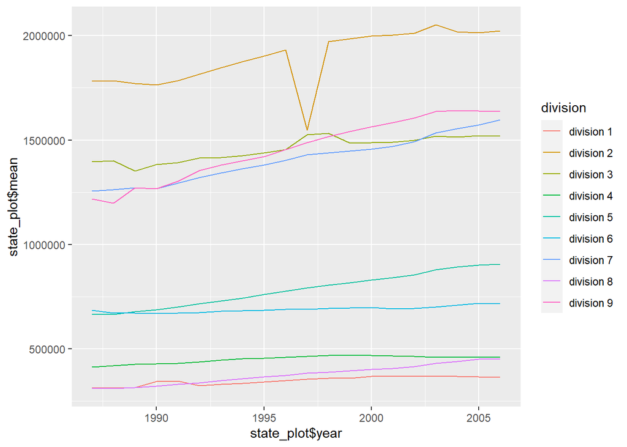

```r
state = as.data.frame(bind[2])
class(state) = c("state", class(state))
plot(state)
```

## Plot `county` data

```r
county = as.data.frame(bind[1])
class(county) = c("county", class(county))
```

### Specify `PA`, group top 7

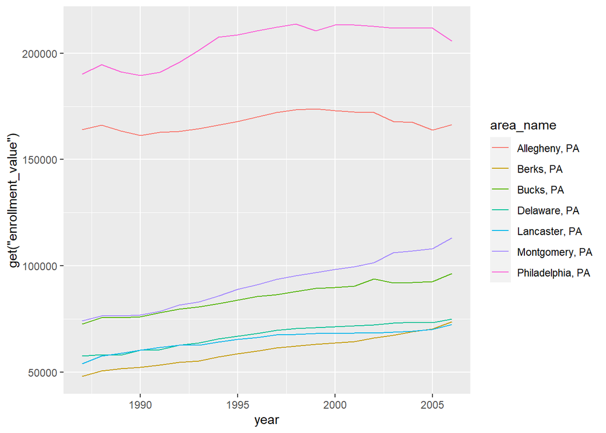

```r
plot(county,"PA","top",7)
```

### Specify `PA`, group bottom 4

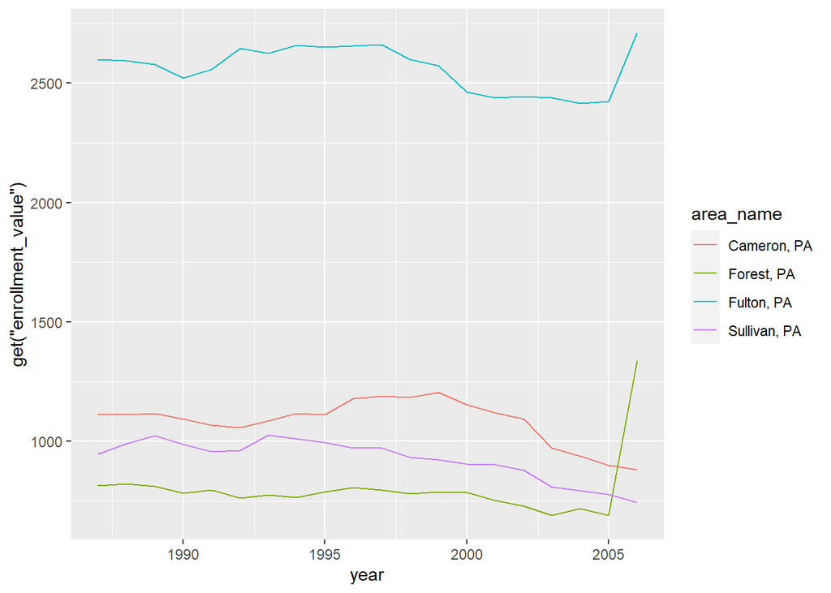

```r
plot(county,"PA","bottom",4)
```

### Default plot

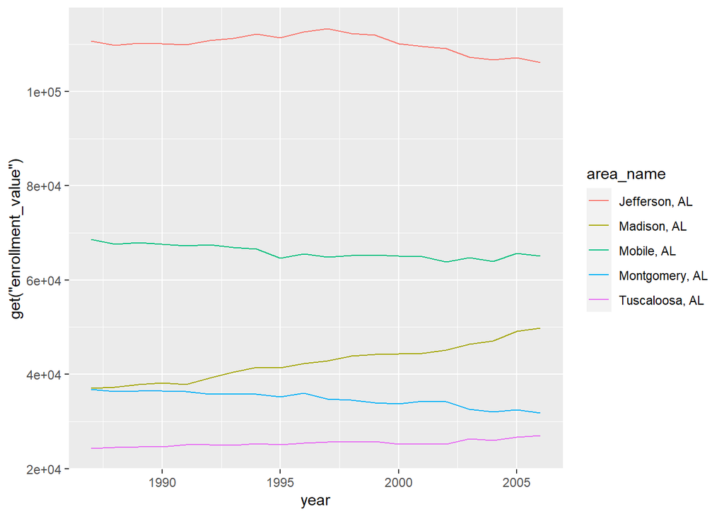

```r
plot(county)
```

### Specify `MN`, group top 10

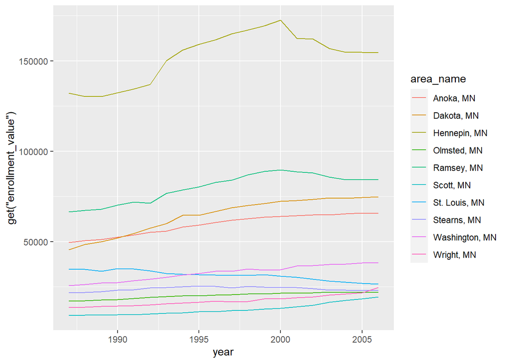

```r
plot(county,"MN","top",10)
```

## Data processing for four datasets

```r
sheet3_result = my_wrapper("https://www4.stat.ncsu.edu/~online/datasets/PST01a.csv", value = "enrollment_value")
sheet4_result = my_wrapper("https://www4.stat.ncsu.edu/~online/datasets/PST01a.csv", value = "enrollment_value")
sheet5_result = my_wrapper("https://www4.stat.ncsu.edu/~online/datasets/PST01c.csv", value = "enrollment_value")
sheet6_result = my_wrapper("https://www4.stat.ncsu.edu/~online/datasets/PST01d.csv", value = "enrollment_value")
```

## Combine datasets

```r
bind1 = fun6(sheet3_result,sheet4_result)
bind2 = fun6(bind1, sheet5_result)
bind3 = fun6(bind2, sheet6_result)
```

## Plot `state` dataset

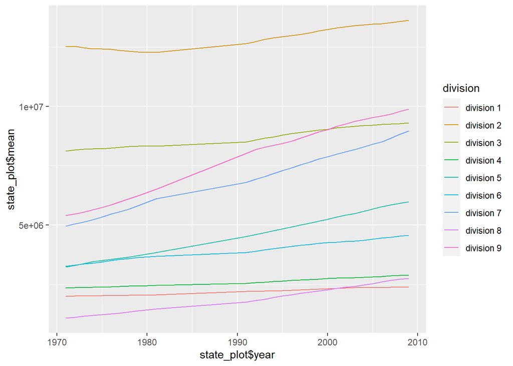

```r
state2 = as.data.frame(bind3[2])
class(state2) = c("state", class(state2))
plot(state2)
```

## Plot `county` dataset

```r
county2 = as.data.frame(bind3[1])
class(county2) = c("county", class(county2))
```

### Specify `CT`, group top 6

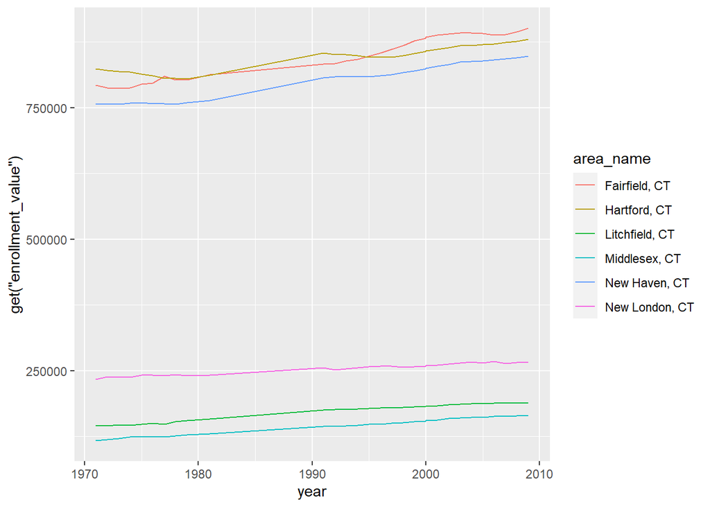

```r
plot(county2,"CT","top",6)
```

### Specify `NC`, group bottom 10

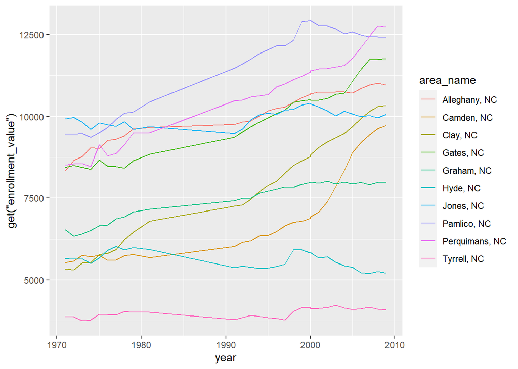

```r
plot(county2,"NC","bottom",10)
```

### Default plot

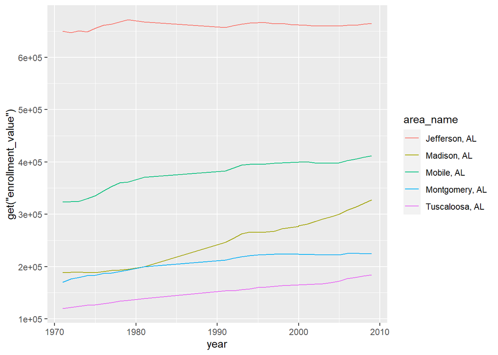

```r
plot(county2)
```

### Specify `MN`, group top 4

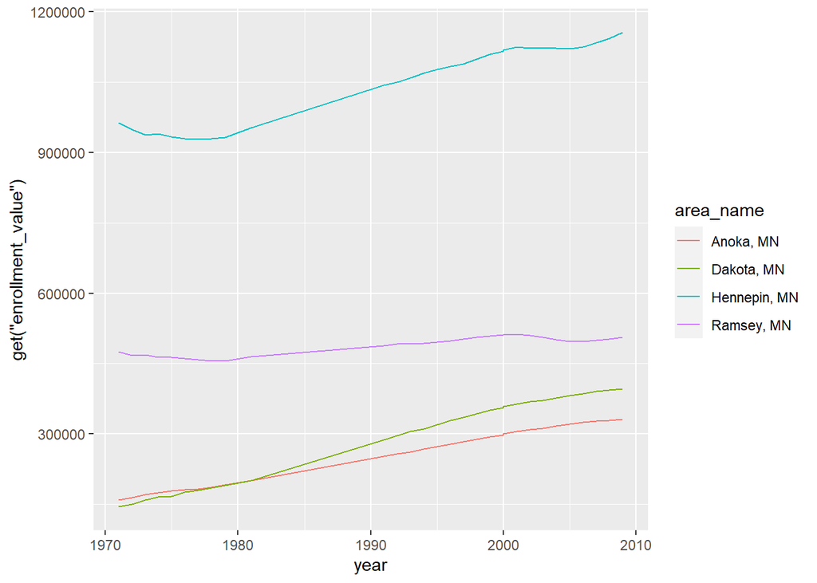

```r
plot(county2,"MN","top",4)
```